# Mineração de Dados 1

# Mineração de dados

## O que é?

- Estamos vivendo em uma era em que a disponibilidade de dados é cada vez maior e a quantidade, cada vez mais abundante.
- Em curtos períodos de tempo, gera-se mais dados que em muitos séculos da história da humanidade (Castro e Ferrari 2016).
- Com o avanço da tecnologia da informação, ferramentas, métodos e algoritmos para se trabalhar com grandes quantidades de dados e tranformá-los em informação e conhecimento são uma necessidade. Neste contexto, a **mineração de dados** (*data mining*) tem um importante papel.
- De forma resumida, a mineração de dados consiste no processo de exploração e análise de massas de dados, com o objetivo de detectar padrões e extrair informação que possibilitem o aprendizado e tomada de decisão.
- De acordo com Han, Kamber, e Pei (2011), o termo “mineração de dados” não reflete a real natureza do processo; um termo mais adequado poderia ser “mineração de conhecimento a partir de dados”.
- Assim, de forma ainda mais resumida, a mineração de dados consiste em extrair “minerar” conhecimento a partir de grandes quantidades de dados.

## Origens

- O termo “mineração de dados” foi cunhado na década de 1990, como uma área, mas o processo de indentificar padrões a partir de dados tem longa história na matemática, estatística e computação.
- Métodos de análise de regressão, por exemplo, remontam aos anos 1800; métodos de clusterização e redes neurais, à década de 1950; e árvores de decisão, à decada de 1960.
- O avanço da tecnologia da informação e da computação tem permitido o desenvolvimento de técnicas de armazenamento e processamento de dados em volumes cada vez maiores.
- A mineração de dados ganhou evidência com o surgimento do termo *Big Data*, que faz referência a esses grandes volumes de dados.
- Hoje em dia, dados em grandes quantidades são facilmente encontrados e fazem parte da rotina do cientista de dados, que, ao mesmo tempo, enfrentam o desafio e têm a oportunidade de analisá-los (Shmueli et al. 2017).

## Aspectos e objetivos

- Aspectos relevantes da mineração de dados incluem:
  - definição e entendimento da proposta de mineração de dados;
  - obtenção, exploração, integração, organização e limpeza dos dados;
  - escolha de métodos, técnicas, modelos e algoritmos a serem utilizados;
  - interpretação dos resultados, identificação de padrões relevantes;
  - apresentação dos resultados “minerados”, divulgação e visualização da informação obtida.
- Objetivos da mineração de dados incluem:
  - **classificação**: um investimento é de baixo, médio ou alto risco?
  - **previsão**: quanto espera-se que um comprador gaste de acordo com seu perfil?
  - **associação**: o desempenho de um medicamento está associado a características do paciente?
  - **redução de dimensão**: posso reduzir o número de variáveis na base de dados sem perder de forma a ganhar eficiência e sem perder informação relevante?
  - **exploração e visualização**: como explorar a base de dados e como visualizar a informação de maneira adequada?

# Tópicos abordados no curso

- No curso, abordaremos conceitos de mineração de dados ao mesmo tempo em que exploraremos diversas ferramentas e possibilidades que a linguagem *R* oferece para tal.
- De maneira resumida, os tópicos a serem abordados em cada aula são apresentados a seguir.

## Aula 1

- Primeiros passos no *R*: comandos e operações básicas, tipos de objetos, manipulação de objetos.
- Importação e exportação de bancos de dados, exportação de gráficos, importação e exportação de objetos.
- Análise exploratória de dados: classificação de variáveis (atributos, *features*), análise gráfica de variáveis qualitativas e quantitativas, medidas-resumo.

## Aula 2

- *R Markdown*: criação de notebooks e documentos.
- Instalação de pacotes.
- Criação de funções.
- Estruturas de controle: `for`, `if`, `else`, `ifelse`, `while`.
- Análise bidimensional de dados: análise gráfica de variáveis qualitativas e quantitativas, ferramentas de visualização, medidas de associação.

## Aula 3

- Representação gráfica de funções unidimensionais e bidimensionais.
- Distribuições de probabilidade: variáveis aleatórias discretas e contínuas.
- Processamento de texto: operações com *strings*, limpeza de dados, exploração e análise, visualização.

## Aula 4

- Pacote `ggplot2` para análise gráfica: estrutura e exemplos de aplicação.
- Métodos de redução de dimensão: análise de correlação, análise de componentes principais.
- Análise de componentes principais para identificação de agrupamentos e para previsão.

## Aula 5

- Encadeamento de funções: operador *pipe*.
- Análise de *cluster*: medidas de dissimilaridade, clusterização hierárquica e dendograma, *k-means*.
- Árvores de regressão e árvores de classificação.

## Aula 6

- Análise temporal e espacial de dados: gráficos de séries temporais, médias móveis, criação de mapas em geral e mapas cloropléticos.
- Pacote `plotly` para análise gráfica.
- Criação de *dashboards* e tabelas interativas.
- Criação de aplicativos interativos por meio do pacote `shiny`.

# Sobre o *R*

## Apresentação

[figure not shown]

*Logo atual do R.*

- O *R* é uma linguagem interativa para computação estatística (R Core Team 2019).
- Possui uma vasta biblioteca de funções estatísticas e matemáticas, além de uma extensa variedade de técnicas gráficas simples e sofisticadas.
- Conta com uma crescente variedade de pacotes para os mais diversos tipos de análises de dados.
- Estudantes e pesquisadores das mais diversas áreas estão se voltando para a utilização do *R*.

“*R* allows statisticians to do very intricate and complicated analysis without knowing the blood and guts of computing systems.” - Daryl Pregibon (ex-pesquisador do Google)

## História

- O *R* começou a ser desenvolvido por Robert Gentleman e Ross Ihaka, do Departamento de Estatística da Universidade de Auckland, Nova Zelândia.
- Por que *R*?

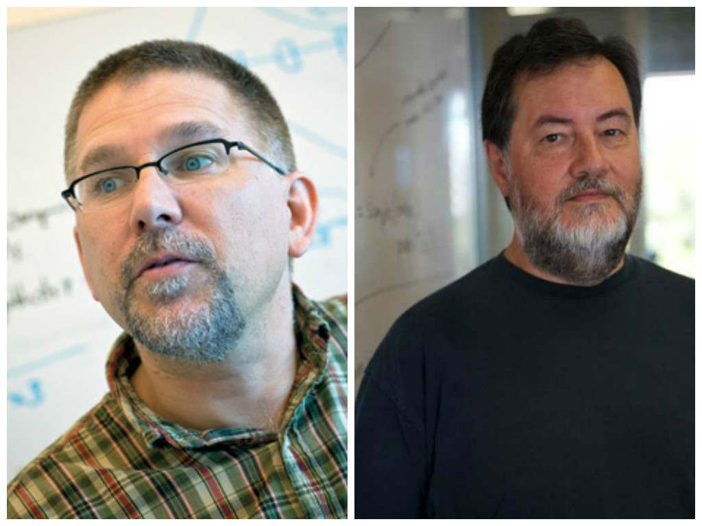

**R**obert Gentleman e **R**oss Ihaka.

- Em 1991, o objetivo inicial de “R & R” era produzir um software para as suas aulas de laboratório baseado na revolucionária linguagem *S*, utilizada pelo software comercial *S-Plus*.
- O *S-Plus* foi criado por Jonh Chambers, da AT&T, e alguns colegas, que hoje em dia é um dos colaboradores que atuam no desenvolvimento e aperfeiçoamento do R.
- O primeiro relato da distribuição do *R* foi em 1993, quando algumas cópias foram disponibilizadas no StatLib, um sistema de distribuição de softwares estatísticos.
- Em 1995, com o incentivo de um dos primeiros usuários deste programa, Martin Mächler, do Instituto Federal de Tecnologia de Zurique, Suíça, “R & R” disponibilizaram o código fonte do *R*.
- Em 1997 foi formado um grupo de profissionais que têm acesso ao código fonte do *R*, possibilitando assim a atualização mais rápida do software.

## Vantagens

- Facilidade no manuseio e armazenamento de dados.
- Operadores vetoriais e matriciais.
- Uma ampla e coerente variedade de ferramentas para análise de dados que atua de forma integrada.
- Facilidades gráficas como a confecção imediata de figuras que podem ser salvas em diversos formatos.
- Linguagem de programação simples e eficiente.
- Integração com outros, por exemplo, C++ e STAN.

# Primeiros passos

## Instalação

- O *R* é gratuito e pode ser obtido em http://www.r-project.org.
- Na opção CRAN, selecione o servidor do qual pretende baixar o software; em seguida, escolha a plataforma (Linux, MAC ou Windows) e obedeça as instruções de download.
- Recentemente, os usuários do *R* têm se voltado para a utilização do *RStudio* (RStudio Team 2020).
- O *RStudio* é uma ferramenta de desenvolvimento integrado para o *R* e instalada à parte.
- Recentemente, tem desenvolvido uma série pacotes muito releventes e populares, tais como o *RMarkdown* e o *Shiny*.
- O *RStudio* tem ferramentas gratuitas e pagas; pode ser obtido em https://rstudio.com.

## Ambiente

- O *R* trabalha com linhas de comando: *você manda (digita o comando e tecla enter)* $\rightarrow$ *ele executa*.
- Os comandos são executados no *console*.
- Ao abrir o *R* ou o *RStudio*, pode-se imediatemente identificar a janela do *console*.
- Cada linha executa um ou mais comandos; se há mais de um comando por linha, eles devem ser separados por “;” (ponto-e-vírgula.)

### Exemplos (operações básicas)

Operações básicas:

```r
5+2   # soma
```

```
## [1] 7
```

```r
10-7   # diferença
```

```
## [1] 3
```

```r
3*2.5   # multiplicação
```

```
## [1] 7.5
```

```r
10/6   # divisão
```

```
## [1] 1.666667
```

```r
3^2; 3**2   # exponenciação
```

```
## [1] 9
```

```
## [1] 9
```

```r
3==3; 4==3; 3!=2; 4!=4 # igual e diferente
```

```
## [1] TRUE
```

```
## [1] FALSE
```

```
## [1] TRUE
```

```
## [1] FALSE
```

```r
2<3; 2>2; 3<=4; 9>=9  # desigualdades
```

```
## [1] TRUE
```

```
## [1] FALSE
```

```
## [1] TRUE
```

```
## [1] TRUE
```

- O *R* utiliza **funções** para realizar operações.
- Para rodar uma função, digitamos seu o nome e, entre parênteses, seus argumentos.

### Exemplos (funções básicas)

```r
cos(10); log(1); abs(5-12); sqrt(25); gamma(5)   # algumas funções matemáticas básicas
```

```
## [1] -0.8390715
```

```
## [1] 0
```

```
## [1] 7
```

```
## [1] 5
```

```
## [1] 24
```

```r
choose(5,2)*0.2^2*(1-0.2)^(5-2)
```

```
## [1] 0.2048
```

```r
dbinom(2,5,0.2)   # cálculo direto
```

```
## [1] 0.2048
```

Se $X\sim Poi(2,5)$, então
$$P(X=3) = \frac{e^{-2,5}2,5^{3}}{3!}.$$

```r
exp(-2.5)*2.5^3/factorial(3)
```

```
## [1] 0.213763
```

```r
dpois(3,2.5)    # cálculo direto
```

```
## [1] 0.213763
```

- Se um comando está incompleto em uma linha, ele pode continuar na linha seguinte.

### Exemplos (comandos em linhas diferentes)

```r
2+
  3
```

```
## [1] 5
```

```r
log(5
    ) + log(3) -
  2
```

```
## [1] 0.7080502
```

- Para detalhes sobre as funções do *R*, podemos acessar o *help*; o que pode ser feito de diferentes formas.

### Exemplos (*help*)

```r
help(choose)   # help de uma função
?choose   # equivalente ao comando anterior
help.search("exponential")   # help por palavra-chave
??exponential   # equivalente ao comando anterior
```

## Objetos

- O *R* é uma linguagem orientada a objetos armazenados na memória ativa do computador.
- A tais objetos são atribuídos valores, expressões.

### Exemplos (atribuição)

Vamos atribuir o valor *10* a um objeto chamado *x*; podemos fazê-lo de duas formas:

```r
x <- 10
x = 10
```

Vamos atribuir o valor $e^{1}$ a um objeto chamado *y*:

```r
y <- exp(1)
```

- O nome do objeto precisa começar com uma letra, pode conter números, ponto, *underline*, mas não pode conter símbolos como vírgula, ponto-e-vírgula ou espaço.
- Os objetos (variáveis) ficam armazenados na memória do computador e podem ser acessados ou manipulados.

### Exemplos (operações com objetos)

```r
x
```

```
## [1] 10
```

```r
y
```

```
## [1] 2.718282
```

```r
x + y
```

```
## [1] 12.71828
```

```r
x/y
```

```
## [1] 3.678794
```

```r
x^2 - log(y)
```

```
## [1] 99
```

Alguns comandos úteis para listar e remover objetos são:

```r
ls()   # lista os objetos na memória do computador
```

```
## [1] "x" "y"
```

```r
rm(x)   # remove um objeto da memória do computador, neste caso o objeto x
```

```r
ls()
```

```
## [1] "y"
```

```r
rm(list=ls())   # remove todos os objetos da memória do computador
```

```r
ls()
```

```
## character(0)
```

```r
gc()   # limpa o "lixo" da memória do computador
```

```
##          used (Mb) gc trigger (Mb) max used (Mb)
## Ncells 424255 22.7     901490 48.2   621334 33.2
## Vcells 762634  5.9    8388608 64.0  1600023 12.3
```

- Alguns dos objetos mais comumente utilizados no *R* são:
  - **vetores**: conjuntos de elementos de uma mesma classe;
  - **matrizes**: conjuntos de elementos de uma mesma classe organizados em linhas e colunas;
  - *arrays*: generalização da ideia de matriz;
  - *data frames*: similar às matrizes, porém diferentes colunas podem possuir elementos de classes diferentes;
  - **listas**: generalização de vetores, representa uma coleção de objetos.

## *Scripts*

- A melhor maneira de programar no *R* não é digitando e executando os comandos diretamente no *console*, mas usando *scripts*.
- Um *script* do *R* é uma série de comandos que podem eventualmente ser executados; inclusive, todos de uma vez.
- Um *script* pode ser escrito em qualquer editor de texto, como o bloco de notas, por exemplo; mas o *R* e o *RStudio* fornecem seus próprios editores.
- A vantagem de se trabalhar com *scripts* é que os comandos podem ser organizados, salvos, editados, assim como rotinas mais complexas podem ser criadas e posteriormente executadas.

### Exemplo (*script*)

Vamos criar um *script* com uma rotina no *R* em que declaramos a nota de 5 alunos em uma prova e então calculamos a média aritmética.

```r
ana <- 10
bernardo <- 9.5
carolina <- 8.9
daniela <- 9.8
eleno <- 7.5
soma <- ana + bernardo + carolina + daniela + eleno
media <- soma/5
media
```

```
## [1] 9.14
```

## Vetores

- Existem diferentes formas de se criar um vetor no *R*.
- Uma das mais básicas é utilizando o comando de **concatenação**.

### Exemplos (criação a manipulação de vetores)

Vamos criar um vetor com as notas dos alunos do exemplo anterior e executar algumas operações.

```r
notas <- c(10,9.5,8.9,9.8,7.5)   # concatenação
notas
```

```
## [1] 10.0  9.5  8.9  9.8  7.5
```

```r
class(notas)   # retorna a classe de um objeto
```

```
## [1] "numeric"
```

*Quantos alunos há?*

```r
n <- length(notas)   # tamanho do vetor
n
```

```
## [1] 5
```

*Qual a nota máxima e a nota mínima?*

```r
nmax <- max(notas)   # retorna o máximo
nmax
```

```
## [1] 10
```

```r
nmin <- min(notas)   # retorna o mínimo
nmin
```

```
## [1] 7.5
```

*Qual é a soma das notas dos alunos?*

```r
soma <- sum(notas)   # retorna a soma
soma
```

```
## [1] 45.7
```

*Qual é a média das notas dos alunos?*

```r
media <- soma/n  # cálculo da média
media <- mean(notas)   # cálculo (direto) da média
media
```

```
## [1] 9.14
```

- A posição de um vetor é sempre representada por colchetes.

### Exemplos (posições em vetores)

*Qual é a nota do segundo aluno?*

```r
notas[2]   # segunda posição do vetor
```

```
## [1] 9.5
```

*Qual é a posição do aluno com a nota nota máxima e a posição do aluno com a nota mínima?*

```r
imax <- which.max(notas)   # retorna a posição do máximo
imax
```

```
## [1] 1
```

```r
imin <- which.min(notas)   # retorna a posição do mínimo
imin
```

```
## [1] 5
```

*Qual é a média das notas dos alunos sem a nota máxima?*

```r
notas2 <- notas[-imax]   # retirando o elemento da posição imax
notas2
```

```
## [1] 9.5 8.9 9.8 7.5
```

```r
media2 <- mean(notas2)
media2
```

```
## [1] 8.925
```

- Um vetor não precisa ser numérico; ele pode ser, por exemplo, um vetor de caracteres ou um vetor lógico.

### Exemplos (vetores de caracteres e lógicos)

Vamos criar um vetor com os nomes dos alunos e executar algumas operações.

```r
nomes <- c("Ana","Bernardo","Carolina","Daniela","Eleno")   # vetor de caracteres
nomes
```

```
## [1] "Ana"      "Bernardo" "Carolina" "Daniela"  "Eleno"
```

```r
class(nomes)
```

```
## [1] "character"
```

*Qual a nota do Bernardo?*

```r
notas[nomes=="Bernardo"]
```

```
## [1] 9.5
```

*Quais são as notas dos alunos sem a nota da Carolina?*

```r
notas[nomes!="Carolina"]
```

```
## [1] 10.0  9.5  9.8  7.5
```

*Notas são maiores que 9?*

```r
tf <- notas>9
tf
```

```
## [1]  TRUE  TRUE FALSE  TRUE FALSE
```

```r
class(tf)
```

```
## [1] "logical"
```

## Matrizes

- Existem diferentes formas de se declarar uma matriz no *R*.
- Uma da formas mais básicas é utilizando o comando de **concatenação de vetores/matrizes** ou o comando de **criação de matriz**.

### Exemplos (criação e manipulação de matrizes)

Suponha que os alunos do exemplo anterior fizeram uma segunda prova; queremos construir uma matriz em que as *colunas* correspondam às notas em cada uma das provas.

```r
notas1 <- c(10,9.5,8.9,9.8,7.5)   # vetor com notas da primeira prova
notas2 <- c(9.9,8,7.5,9,8)   # vetor com notas da segunda prova
notas <- cbind(notas1,notas2)   # concatenação dos vetores por coluna
notas
```

```
##      notas1 notas2
## [1,]   10.0    9.9
## [2,]    9.5    8.0
## [3,]    8.9    7.5
## [4,]    9.8    9.0
## [5,]    7.5    8.0
```

```r
class(notas)
```

```
## [1] "matrix"
```

Queremos agora construir uma matriz em que as *linhas* correspondam às notas em cada uma das provas.

```r
notas <- rbind(notas1,notas2)   # concatenação de matrizes por linha
notas
```

```
##        [,1] [,2] [,3] [,4] [,5]
## notas1 10.0  9.5  8.9  9.8  7.5
## notas2  9.9  8.0  7.5  9.0  8.0
```

```r
class(notas)
```

```
## [1] "matrix"
```

*Considerando a concatenação por linhas, qual é a nota do terceiro aluno na segunda prova?*

```r
notas[2,3]   # as posições são sempre [linha,coluna]
```

```
## notas2
##    7.5
```

*Qual é a média das notas na primeira prova?*

```r
media1 <- mean(notas[1,])   # notas[1,] corresponde a um vetor com a linha 1
media1
```

```
## [1] 9.14
```

*Qual é a média das notas do quarto aluno?*

```r
media2 <- mean(notas[,4])   # notas[,4] corresponde a um vetor com a coluna 4
media2
```

```
## [1] 9.4
```

Outra forma de construir uma matriz em que as *colunas* correspondam às notas em cada uma das provas é:

```r
notasaux <- c(notas1,notas2)   # vetor com todas as notas
notasaux
```

```
##  [1] 10.0  9.5  8.9  9.8  7.5  9.9  8.0  7.5  9.0  8.0
```

```r
notas <- matrix(notasaux,5,2)   # a organização default é por coluna
notas
```

```
##      [,1] [,2]
## [1,] 10.0  9.9
## [2,]  9.5  8.0
## [3,]  8.9  7.5
## [4,]  9.8  9.0
## [5,]  7.5  8.0
```

Para construir uma matriz em que as *linhas* correspondam às notas em cada uma das provas, podemos proceder como:

```r
notas <- matrix(notasaux,2,5,byrow=TRUE)   # habilitamos a opção de ordenação por linha
notas
```

```
##      [,1] [,2] [,3] [,4] [,5]
## [1,] 10.0  9.5  8.9  9.8  7.5
## [2,]  9.9  8.0  7.5  9.0  8.0
```

- Operações básicas com vetores ou matrizes, como a multiplicação, por exemplo, são feitas elemento a elemento.
- A maioria das funções que podem ser aplicadas em um escalar, quando aplicadas em vetores e matrizes são também aplicadas em cada elemento.

### Exemplos (operações com matrizes)

Vamos declarar as matrizes
$$A = \left[\begin{array}{ccc}2 & 2 & 2 \\ 2 & 2 & 2\end{array}\right],\;
B = \left[\begin{array}{ccc}1 & 3 & 5 \\ 2 & 4 & 6\end{array}\right]\;\;\mbox{e}\;\;
C = \left[\begin{array}{cc} 5 & 7 \\ 3 & 4 \\ 2 & 1\end{array}\right]$$
e executar algumas operações.

```r
A <- matrix(2,2,3)
B <- matrix(1:6,2,3)
C <- matrix(c(5,3,2,7,4,1),3,2)
A
```

```
##      [,1] [,2] [,3]
## [1,]    2    2    2
## [2,]    2    2    2
```

```r
B
```

```
##      [,1] [,2] [,3]
## [1,]    1    3    5
## [2,]    2    4    6
```

```r
C
```

```
##      [,1] [,2]
## [1,]    5    7
## [2,]    3    4
## [3,]    2    1
```

```r
A*B   # produto elemento a elemento
```

```
##      [,1] [,2] [,3]
## [1,]    2    6   10
## [2,]    4    8   12
```

```r
exp(A)   # função aplicada em cada elemento
```

```
##          [,1]     [,2]     [,3]
## [1,] 7.389056 7.389056 7.389056
## [2,] 7.389056 7.389056 7.389056
```

```r
1/A   # elementos inversos
```

```
##      [,1] [,2] [,3]
## [1,]  0.5  0.5  0.5
## [2,]  0.5  0.5  0.5
```

```r
D <- B%*%C   # produto matricial
D
```

```
##      [,1] [,2]
## [1,]   24   24
## [2,]   34   36
```

```r
solve(D)   # matriz inversa
```

```
##            [,1] [,2]
## [1,]  0.7500000 -0.5
## [2,] -0.7083333  0.5
```

```r
t(B)   # matriz transposta
```

```
##      [,1] [,2]
## [1,]    1    2
## [2,]    3    4
## [3,]    5    6
```

```r
dim(C)   # dimensões da matriz
```

```
## [1] 3 2
```

## *Data frames*

- Os *data frames* são os objetos básicos para se “guardar” um conjunto de dados.
- Por poder ter elementos de diferentes classes, pode representar diversos tipos de dados.

### Exemplos (criação de *data frames*)

Considerando os dados do exemplo anterior, queremos criar um objeto em que a primeira coluna corresponda aos nomes dos alunos e as demais, às notas.

Vamos criar, primeiramente, uma matriz.

```r
nomes
```

```
## [1] "Ana"      "Bernardo" "Carolina" "Daniela"  "Eleno"
```

```r
notas1
```

```
## [1] 10.0  9.5  8.9  9.8  7.5
```

```r
notas2
```

```
## [1] 9.9 8.0 7.5 9.0 8.0
```

```r
m <- cbind(nomes,notas1,notas2)
m
```

```
##      nomes      notas1 notas2
## [1,] "Ana"      "10"   "9.9"
## [2,] "Bernardo" "9.5"  "8"
## [3,] "Carolina" "8.9"  "7.5"
## [4,] "Daniela"  "9.8"  "9"
## [5,] "Eleno"    "7.5"  "8"
```

O problema é que as notas se tornaram caracteres, pois matrizes só podem ter elementos da mesma natureza.

Se quiseremos calcular a média das notas da primeira prova, por exemplo, obtemos:

```r
mean(m[,2])
```

```
## [1] NA
```

A solução é criar, em vez de uma matriz, um *data frame*, que preserva a classe dos objetos concatenados.

```r
m2 <- data.frame(nomes,notas1,notas2)   # funciona como um cbind
m2
```

```
##      nomes notas1 notas2
## 1      Ana   10.0    9.9
## 2 Bernardo    9.5    8.0
## 3 Carolina    8.9    7.5
## 4  Daniela    9.8    9.0
## 5    Eleno    7.5    8.0
```

```r
class(m2)
```

```
## [1] "data.frame"
```

```r
mean(m2[,2])
```

```
## [1] 9.14
```

Podemos renomear o nome das colunas do *data frame*.

```r
names(m2) <- c("Alunos","P1","P2")
m2
```

```
##     Alunos   P1  P2
## 1      Ana 10.0 9.9
## 2 Bernardo  9.5 8.0
## 3 Carolina  8.9 7.5
## 4  Daniela  9.8 9.0
## 5    Eleno  7.5 8.0
```

Podemos também nos referir a uma coluna pelo nome, em vez do número.

```r
m2["Alunos"]
```

```
##     Alunos
## 1      Ana
## 2 Bernardo
## 3 Carolina
## 4  Daniela
## 5    Eleno
```

```r
m2["P1"]
```

```
##     P1
## 1 10.0
## 2  9.5
## 3  8.9
## 4  9.8
## 5  7.5
```

```r
m2["P2"]
```

```
##    P2
## 1 9.9
## 2 8.0
## 3 7.5
## 4 9.0
## 5 8.0
```

# Exemplo 1 - Livros mais vendidos da *Amazon*

- O banco de dados contém informações sobre 50 livros mais vendidos da *Amazon* por ano entre 2009 a 2019.
- Os dados podem ser baixados em https://www.kaggle.com/sootersaalu/amazon-top-50-bestselling-books-2009-2019.

## Importando o banco de dados

- O primeiro passo para se trabalhar com um banco de dados no *R* é importá-lo.
- As funções (ou comandos) utilizados para importação dependem da natureza do arquivo com os dados e do local do qual serão importados.

### Arquivo com extensão .csv importado do computador

```r
dados <- read.csv("C:/Users/joaob/OneDrive/Desktop/Dados/bestsellers_amazon.csv")   # importa um arquivo .csv
dados <- read.csv("C:\\Users\\joaob\\OneDrive\\Desktop\\Dados\\bestsellers_amazon.csv")   # importa um arquivo .csv
```

```r
head(dados)   # vislumbre dos dados
```

```
##                                                                 Name
## 1                                      10-Day Green Smoothie Cleanse
## 2                                                  11/22/63: A Novel
## 3                            12 Rules for Life: An Antidote to Chaos
## 4                                             1984 (Signet Classics)
## 5 5,000 Awesome Facts (About Everything!) (National Geographic Kids)
## 6                      A Dance with Dragons (A Song of Ice and Fire)
##                     Author User.Rating Reviews Price Year       Genre
## 1                 JJ Smith         4.7   17350     8 2016 Non Fiction
## 2             Stephen King         4.6    2052    22 2011     Fiction
## 3       Jordan B. Peterson         4.7   18979    15 2018 Non Fiction
## 4            George Orwell         4.7   21424     6 2017     Fiction
## 5 National Geographic Kids         4.8    7665    12 2019 Non Fiction
## 6      George R. R. Martin         4.4   12643    11 2011     Fiction
```

```r
dim(dados)   # dimensão dos dados
```

```
## [1] 550   7
```

Podemos importar o arquivo somente pelo nome ao definir o diretório de trabalho (*working directory*), o que pode ser feito diretamente no menu do *R* ou do *RStudio*, mas também pode ser feito por linhas de comando.

```r
setwd("C:/Users/joaob/OneDrive/Desktop/Dados")   # selecionando diretório de trabalho
getwd()   # mostra o diretório de trabalho
```

```
## [1] "C:/Users/joaob/OneDrive/Desktop/Dados"
```

```r
dados <- read.csv("bestsellers_amazon.csv")
```

### Arquivo .csv importado de um endereço *web*

Vamos agora importar a base de dados disponível em `http://im.ufrj.br/~joao/cienciadedados/bestsellers_amazon.csv`.

```r
dados <- read.csv("http://im.ufrj.br/~joao/cienciadedados/bestsellers_amazon.csv")
```

```r
class(dados)
```

```
## [1] "data.frame"
```

## Variáveis, atributos, *features*

- Dados são feitos de **objetos de dados** (*data objects*).
- Por exemplo, em bases de dados de venda, objetos de dados podem ser consumidores, itens, vendas; em bases de dados de uma universidades, objetos de dados podem ser alunos, professores, funcionários.
- Em geral, objetos de dados são descritos por **variáveis**; também denominadas **atributos** ou *features*.
- É comum, em bases de dados, que objetos de dados sejam organizados nas linhas e variáveis nas colunas (Han, Kamber, e Pei 2011).
- Para melhor se trabalhar com as variáveis, é importante classificá-las.
- Variáveis como nomes e símbolos (sem interpretação numérica) são geralmente chamadas **variáveis qualitativas (ou categóricas)**
- Variáveis qualitativas podem ser **nominais** (sem ordem aparente), como cor de cabelo ou sabor de sorvete; ou podem ser **ordinais** (com ordem aparente), como tamanho (pequeno, médio, grande) ou conceito (C, B- ,B+, A-, A+).
- Variáveis podem também ser **quantitativas (ou numéricas)**.
- Varíaveis quantitativas podem ser **discretas** (conjunto enumerável de valores possíveis), como número de casos de COVID-19; ou podem ser **contínuas** (conjunto não enumerável de valores possíveis), como temperatura.

### Acessando as variáveis da base de dados

```r
names(dados)   # nomes das colunas do objeto
```

```
## [1] "Name"        "Author"      "User.Rating" "Reviews"     "Price"
## [6] "Year"        "Genre"
```

## Análise exploratória (variáveis qualitativas)

### *Genre* (gênero)

Vamos calcular e plotar em um **gráfico de barras** a **frequência absoluta** de cada gênero em todos os anos.

```r
genero <- dados[,7]    # definindo um vetor para o gênero
cont <- table(genero)   # frequência absoluta de cada resposta
cont
```

```
## genero
##     Fiction Non Fiction
##         240         310
```

```r
class(cont)
```

```
## [1] "table"
```

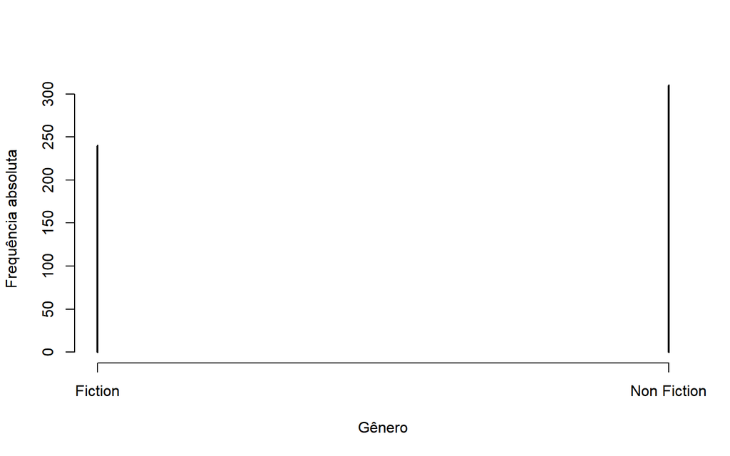

```r
plot(cont,xlab="Gênero",ylab="Frequência absoluta")   # gráfico da frequência absoluta
```

Podemos optar por um gráfico de barras diferente.

```r
ni <- as.numeric(cont)   # tranformando o objeto em um vetor numérico
ni
```

```
## [1] 240 310
```

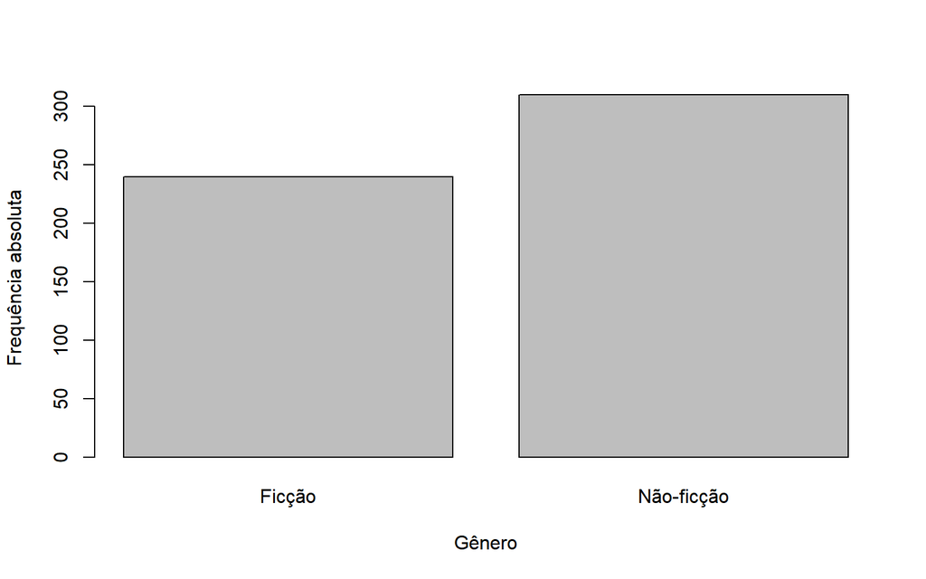

```r
barplot(ni,names=c("Ficção","Não-ficção"),xlab="Gênero",ylab="Frequência absoluta")   # gráfico de barras
```

Podemos estar interessados na **frequência relativa**.

```r
fi <- ni/length(genero) # tranformando o objeto em um vetor numérico
fi
```

```
## [1] 0.4363636 0.5636364
```

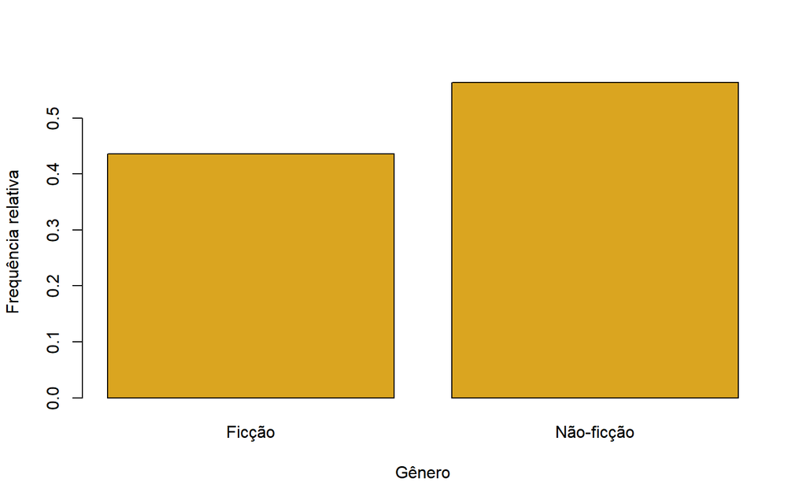

```r
barplot(fi,names=c("Ficção","Não-ficção"),xlab="Gênero",ylab="Frequência relativa",col="goldenrod")   # gráfico de barras
```

Vamos usar porcentagem agora.

```r
por <- fi*100 # tranformando o objeto em um vetor numérico
por
```

```
## [1] 43.63636 56.36364
```

[figure not shown]

```r
barplot(por,names=c("Ficção","Não-ficção"),xlab="Gênero",ylab="Porcentagem",col="light blue",density=25)   # gráfico de barras
```

Podemos preferir um **gráfico de setores (pizza)**.

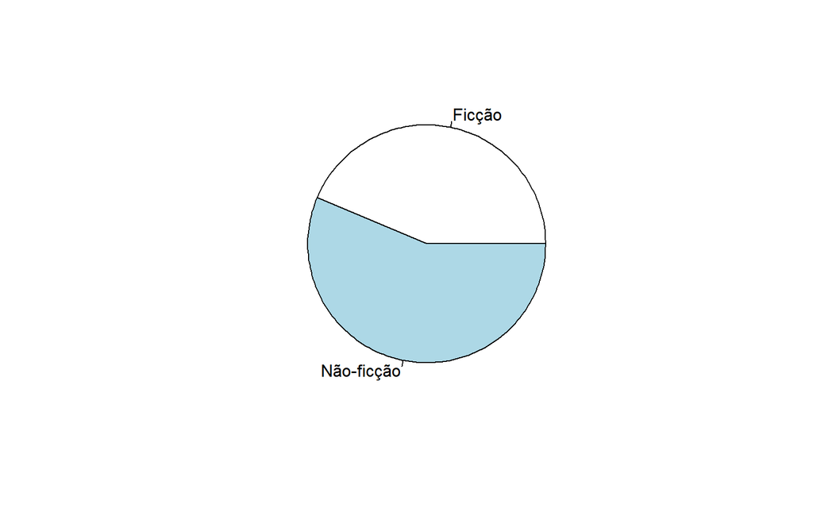

```r
pie(ni,labels=c("Ficção","Não-ficção"))
```

Vamos separar as frequências por ano e compará-las utilizando um **gráfico de série temporal**.

```r
ano <- dados[,6]   # definindo um vetor para os anos
gen.ano <- aggregate(genero~ano,FUN=table)   # agrupa dados por ano e calcula a frequência absoluta
gen.ano
```

```
##     ano genero.Fiction genero.Non Fiction
## 1  2009             24                 26
## 2  2010             20                 30
## 3  2011             21                 29
## 4  2012             21                 29
## 5  2013             24                 26
## 6  2014             29                 21
## 7  2015             17                 33
## 8  2016             19                 31
## 9  2017             24                 26
## 10 2018             21                 29
## 11 2019             20                 30
```

```r
class(gen.ano)
```

```
## [1] "data.frame"
```

```r
dim(gen.ano)
```

```
## [1] 11  2
```

```r
gen.ano2 <- as.matrix(gen.ano)   # transoformando o objeto em uma matriz
dim(gen.ano2)
```

```
## [1] 11  3
```

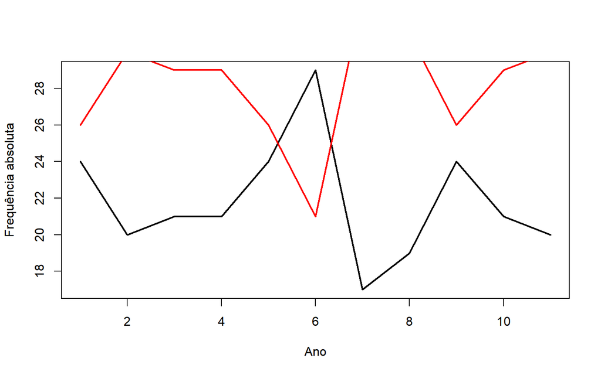

```r
plot(gen.ano2[,2],type="l",lwd=2,col=1,xlab="Ano",ylab="Frequência absoluta")   # gráfico de linha (série temporal)
lines(gen.ano2[,3],lwd=2,col=2)   # gráfico de linha sobreposto ao gráfico ativo
```

Vamos melhorar a apresentação dos dados.

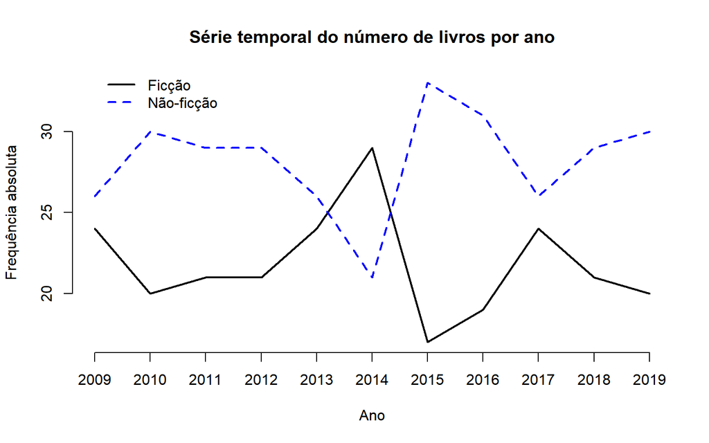

```r
nome.ano <- gen.ano[,1]   # nomes dos anos
inf <- min(gen.ano[,-1])   # limite inferior do eixo y
sup <- max(gen.ano[,-1])   # limite superior do eixo y
plot(gen.ano2[,2],type="l",lwd=2,col=1,xlab="Ano",ylab="Frequência absoluta",ylim=c(inf,sup),axes=FALSE,main="Série temporal do número de livros por ano")
lines(gen.ano2[,3],lwd=2,col=4,lty=2)
axis(1,at=1:length(nome.ano),labels=nome.ano)   # eixo x
axis(2)   # eixo y
legend(1,34,legend=c("Ficção","Não-ficção"),lty=c(1,2),lwd=2,col=c(1,4),bty="n")   # legenda
```

## Análise exploratória (variáveis quantitativas)

### *Reviews* (número de *reviews*)

Vamos investigar como se distribui o número de *reviews* por meio de um **histograma**.

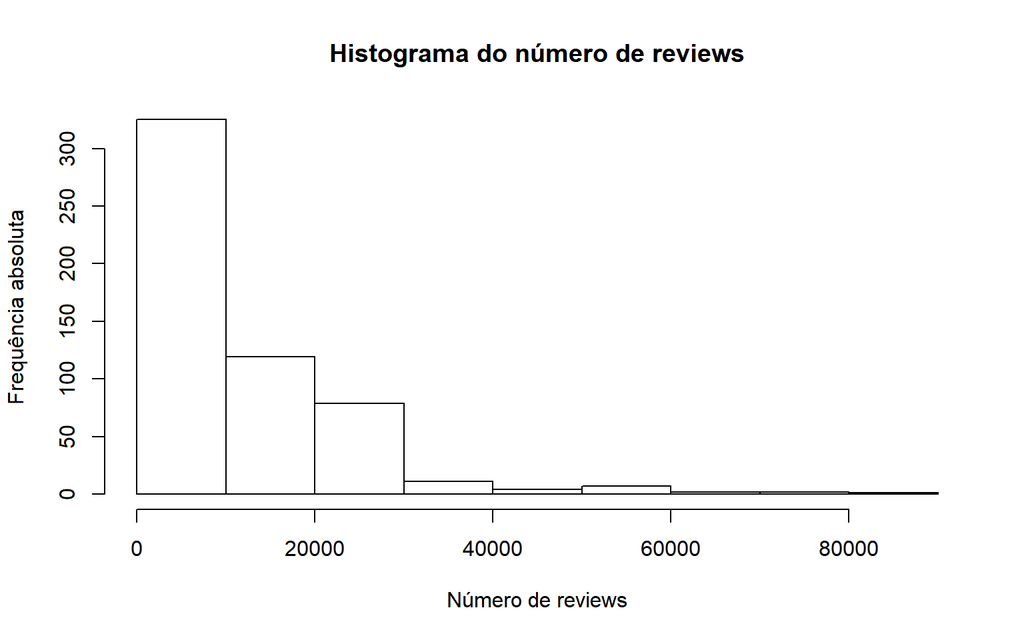

```r
rev <- dados[,4]   # definindo um vetor para o número de reviews
hist(rev,xlab="Número de reviews",ylab="Frequência absoluta",main="Histograma do número de reviews")
```

Podemos fazer um histograma que utiliza, em vez da frequência absoluta, a **densidade de frequência relativa** (área da barra é igual à frequência relativa).

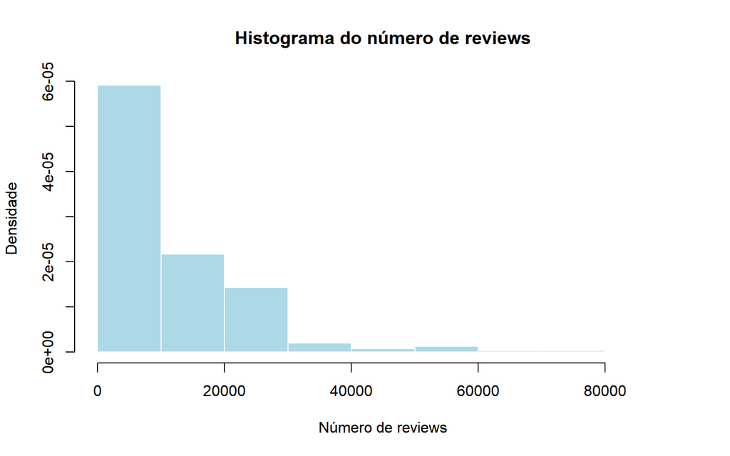

```r
hist(rev,xlab="Número de reviews",ylab="Densidade",main="Histograma do número de reviews",prob=TRUE,border="white",col="light blue")
```

Vamos agora calcular algumas **medidas-resumo**.

Como o próprio nome sugere, medidas-resumo resumem a informação dos dados. **Medidas de centralidade**, tais como a **média** e a **mediana**, dão ideia do “centro” dos dados.

Para um conjunto de dados $x_1,\dots,x_n$, a média (aritmética) é calculada como
$$\overline x = \frac{1}{n}\sum_{i=1}^n x_i.$$
A mediana é o valor que divide o conjunto de dados ao meio, isto é, é o valor tal que 50% dos dados estão acima e 50% dos dados estão abaixo dele.

Para um conjunto de dados ordenado $x_{(1)},\dots,x_{(n)}$, a mediana pode ser calculada como
$$m = x_{\left(\frac{n+1}{2}\right)},$$
se $n$ é ímpar; e
$$m = x_{\left(\frac{n}{2}\right)} + x_{\left(\frac{n}{2}+1\right)},$$
se $n$ é par.

**Medidas de dispersão**, por sua vez, dão ideia de variabilidade. Entre elas estão a **variância amostral**, o **desvio padrão amostral**.

A variância amostral é definida como
$$s^2 = \frac{1}{n-1}\sum_{i=1}^n (x_i - \overline x)^2$$
e desvio padrão amostral como $s=\sqrt{s^2}$.

Podemos facilmente calcular algumas medidas para o número de *reviews*.

```r
mean(rev)
```

```
## [1] 11953.28
```

```r
median(rev)
```

```
## [1] 8580
```

```r
var(rev)
```

```
## [1] 137619458
```

```r
sd(rev)
```

```
## [1] 11731.13
```

Em distribuições com assimetria positiva, como é o caso (vide histograma), a média é maior que a mediana.

A mediana é uma medida menos afetada por valores extremos quando comparada com a média.

Outras medidas que são úteis para resumir a informação nos dados são os **quantis**.

O quantil $p$ de um conjunto de dados, $q(p)$, é o valor do qual uma proporção $p$ dos dados está abaixo e uma proporção $1-p$ está acima.

Alguns dos quantis maus utilizados são os **quartis**: $Q_1=q(0,25)$, $Q_2=q(0,50)$ e $Q_3=q(0,75)$.

```r
quantile(rev,c(0.25,0.5,0.75))
```

```
##      25%      50%      75%
##  4058.00  8580.00 17253.25
```

Medidas-resumos básicas podem ser calculadas todas de uma vez.

```r
summary(rev)
```

```
##    Min. 1st Qu.  Median    Mean 3rd Qu.    Max.
##      37    4058    8580   11953   17253   87841
```

Uma forma alternativa de visualizar a distribuição dos dados é por meio do gráfico *box-plot*.

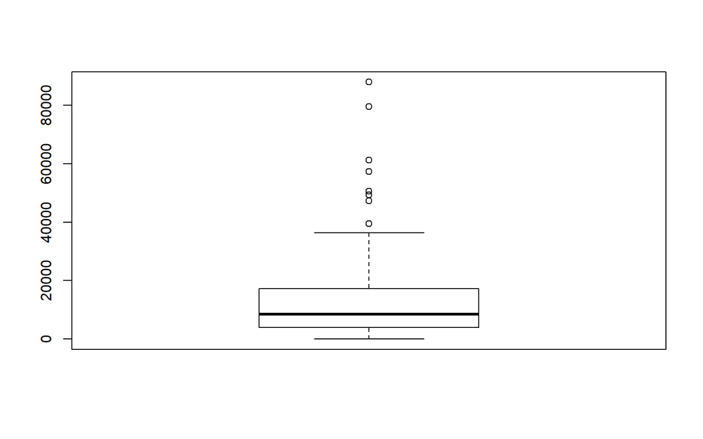

```r
boxplot(rev)
```

A “caixa” corresponde aos quartis; os segmentos correspondem ao menor e maior valores do conjunto de dados, desde que não sejam **discrepantes**.

Uma regra usual para definir valores discrepantes é classificá-los como tal se são menores que
$$LI=Q_1 - 1,5DIQ$$
ou maiores que
$$LS = Q_3 + 1,5DIQ,$$
em que $DIQ=Q_3 - Q_1$ é uma medida de dispersão chamada **distância interquartil**.

Valores discrepantes no *box-plot* são representados por pontos.

Vamos agora comparar a distribuição ao longo dos anos utilizando o *boxplot*.

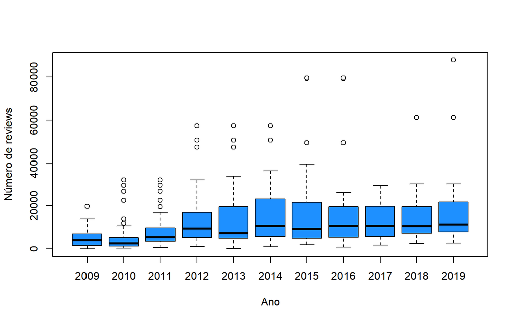

```r
boxplot(rev~ano,xlab="Ano",ylab="Número de reviews",col="dodgerblue1")
```

### *User.Rating* (classificação do usuário)

Vamos fazer algumas análises exploratórias para a classificação do usuário.

```r
userr <- dados[,3]   # definindo um vetor para a classificação
summary(userr)
```

```
##    Min. 1st Qu.  Median    Mean 3rd Qu.    Max.
##   3.300   4.500   4.700   4.618   4.800   4.900
```

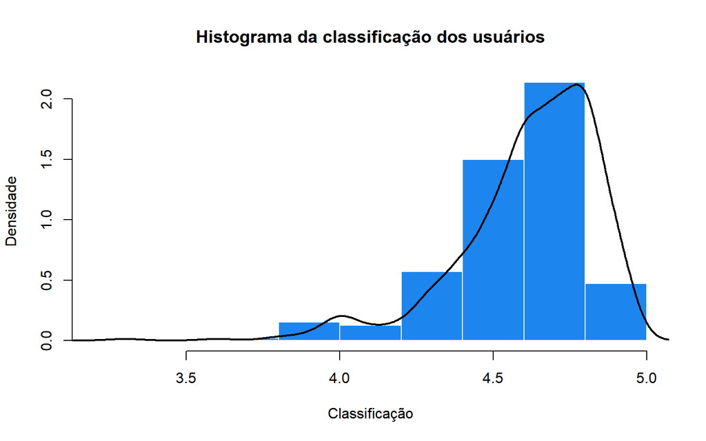

```r
hist(userr,prob=TRUE,col="dodgerblue2",border="white",xlab="Classificação",ylab="Densidade",main="Histograma da classificação dos usuários")
lines(density(userr),lwd=2)   # histograma suavizado
```

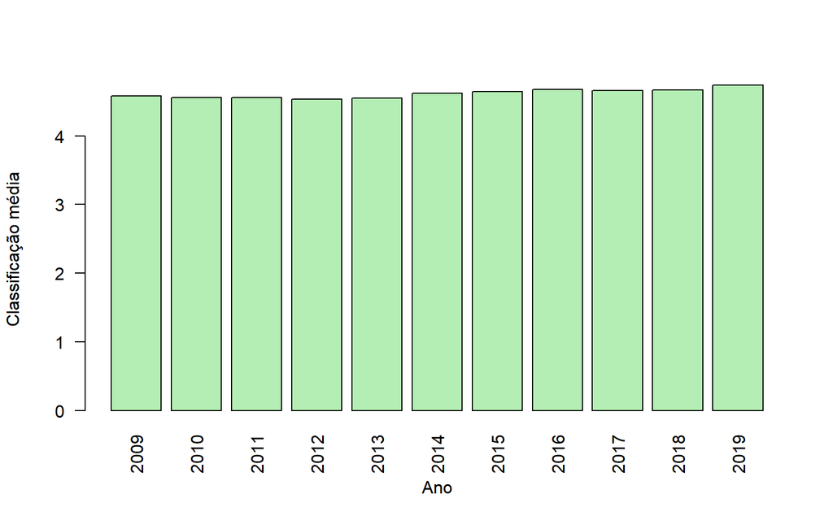

```r
userr.ano <- aggregate(userr~ano,FUN=mean)   # média por ano
barplot(userr.ano[,2],col="darkseagreen2",names=nome.ano,las=2,xlab="Ano",ylab="Classificação média")
```

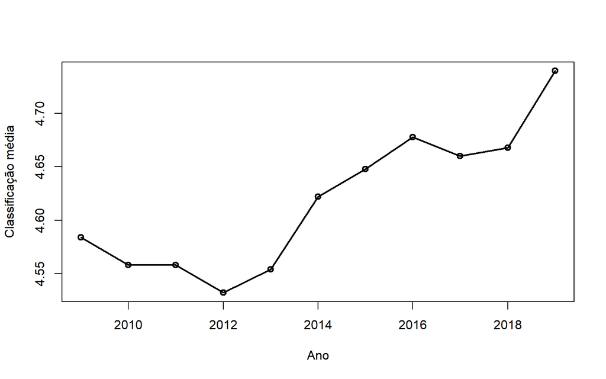

```r
plot(nome.ano,userr.ano[,2],xlab="Ano",ylab="Classificação média",lwd=2,type="o")
```

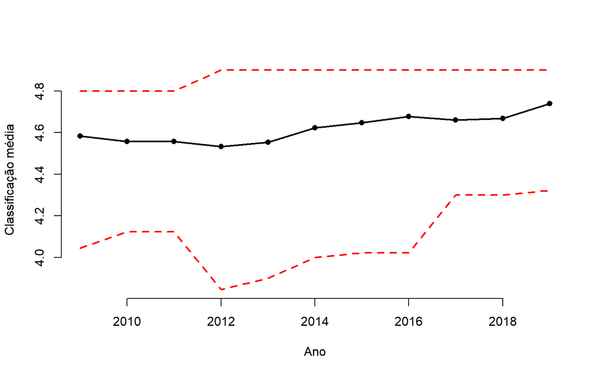

```r
userr.ano.q <- aggregate(userr~ano,FUN=quantile,probs=c(0.025,0.975))   # média por ano
userr.ano.q <- as.matrix(userr.ano.q)
inf <- userr.ano.q[,2]
sup <- userr.ano.q[,3]
plot(nome.ano,userr.ano[,2],xlab="Ano",ylab="Classificação média",lwd=2,type="o",ylim=c(min(inf),max(sup)),bty="n",pch=16)
lines(nome.ano,userr.ano.q[,2],lty=2,col=2,lwd=2)
lines(nome.ano,userr.ano.q[,3],lty=2,col=2,lwd=2)
```

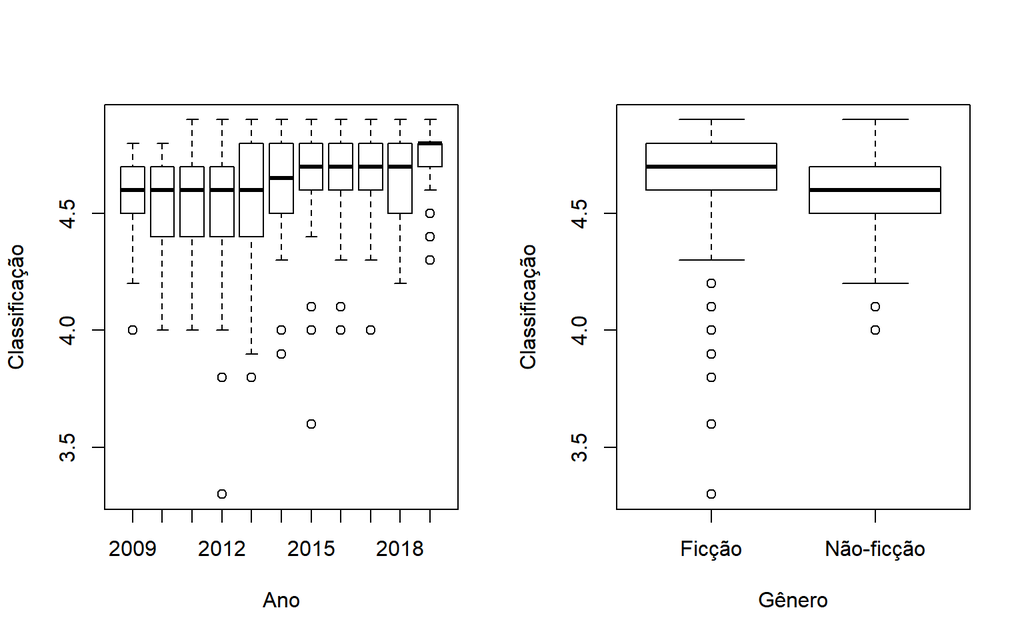

```r
par(mfrow=c(1,2))   # dividindo a janela em duas
boxplot(userr~ano,xlab="Ano",ylab="Classificação")
boxplot(userr~genero,xlab="Gênero",ylab="Classificação",names=c("Ficção","Não-ficção"))
```

## Exportando gráficos

- O *R* e o *RStudio* fornecem ferramentas para exportar gráficos em diversos formatos.
- Além disso, existem funções que permitem com que os gráficos sejam exportados auomaticamente.

### Exportando para arquivo PDF

Podemos exportar em um local específico do computador por meio de algumas funções específicas.

Vamos, inicialmente, exportar um gráfico para um arquivo PDF por meio da função `pdf()`, fornecendo o caminho do arquivo a ser salvo. Há duas maneiras de fazer isto.

```r
pdf("C:/Users/joaob/OneDrive/Desktop/Output/boxplot1.pdf",width=7, height=5)   # abrindo conexão para confecção do gráfico; tamanho está em polegadas

par(mfrow=c(1,2))   # confeccionando gráfico
boxplot(userr~ano,xlab="Ano",ylab="Classificação")
boxplot(userr~genero,xlab="Gênero",ylab="Classificação",names=c("Ficção","Não-ficção"))

dev.off()   # fechando conexão
```

```r
pdf("C:\\Users\\joaob\\OneDrive\\Desktop\\Output\\boxplot1.pdf",width=7, height=5)   # abrindo conexão para confecção do gráfico; tamanho está em polegadas

par(mfrow=c(1,2))   # confeccionando gráfico
boxplot(userr~ano,xlab="Ano",ylab="Classificação")
boxplot(userr~genero,xlab="Gênero",ylab="Classificação",names=c("Ficção","Não-ficção"))

dev.off()
```

Se o caminho caminho do arquivo não é totalmente especificado, mas somente o nome do arquivo, o *R* salvará o arquivo no diretório de trabalho.

```r
setwd("C:/Users/joaob/OneDrive/Desktop/Output")

pdf("boxplot1.pdf",width=7, height=5)   # abrindo conexão para confecção do gráfico; tamanho está em polegadas

par(mfrow=c(1,2))   # confeccionando gráfico
boxplot(userr~ano,xlab="Ano",ylab="Classificação")
boxplot(userr~genero,xlab="Gênero",ylab="Classificação",names=c("Ficção","Não-ficção"))

dev.off()
```

### Exportando para um arquivo .jpeg

Para exportar o gráfico para um arquivo com extensão .jpeg, podemos utilizar a função `jpeg()`

```r
jpeg("C:/Users/joaob/OneDrive/Desktop/Output/boxplot2.jpeg",width=680, height=480)   # abrindo conexão para confecção do gráfico; tamanho está em pixels

par(mfrow=c(1,2))   # confeccionando gráfico
boxplot(userr~ano,xlab="Ano",ylab="Classificação")
boxplot(userr~genero,xlab="Gênero",ylab="Classificação",names=c("Ficção","Não-ficção"))

dev.off()   # fechando conexão
```

Para outras extensões tais como .bmp e .png, basta utilizar a função como o nome correspondente.

## Outras análises exploratórias

Um comando muito útil para e trabalhar com cada variável separadamente é o `attach()`.

Ele permite que chamemos a variável pelo seu nome sem termos que declará-la.

```r
attach(dados)
```

*Qual é o autor que mais apareceu nas listas de mais vendidos considerando todos os anos?*

```r
autortab <- table(Author)   # frequência absoluta para cada autor
ind <- which.max(autortab)   # índice do máximo
ind
```

```
## Jeff Kinney
##         120
```

```r
max(autortab)   # máximo de vezes
```

```
## [1] 12
```

```r
Name[Author=="Jeff Kinney"]   # Livros do autor
```

```
##  [1] Cabin Fever (Diary of a Wimpy Kid, Book 6)
##  [2] Diary of a Wimpy Kid: Hard Luck, Book 8
##  [3] Diary of a Wimpy Kid: The Last Straw (Book 3)
##  [4] Diary of a Wimpy Kid: The Long Haul
##  [5] Dog Days (Diary of a Wimpy Kid, Book 4) (Volume 4)
##  [6] Double Down (Diary of a Wimpy Kid #11)
##  [7] Old School (Diary of a Wimpy Kid #10)
##  [8] The Getaway
##  [9] The Meltdown (Diary of a Wimpy Kid Book 13)
## [10] The Third Wheel (Diary of a Wimpy Kid, Book 7)
## [11] The Ugly Truth (Diary of a Wimpy Kid, Book 5)
## [12] Wrecking Ball (Diary of a Wimpy Kid Book 14)
## 351 Levels: 10-Day Green Smoothie Cleanse ... You Are a Badass: How to Stop Doubting Your Greatness and Start Living an Awesome Life
```

*Qual é o livro que apareceu mais vezes nas lista de mais vendidos considerando todos os anos?*

```r
livrotab <- table(Name)   # frequência absoluta para cada livro
ind <- which.max(livrotab)
ind
```

```
## Publication Manual of the American Psychological Association, 6th Edition
##                                                                       192
```

```r
max(livrotab)
```

```
## [1] 10
```

*Quais os livros que aparecem em cinco ou mais anos nas listas de mais vendidos?*

```r
ind <- which(livrotab>=5)   # índices dos livros que satisfazem a condição
ind
```

```
##                                                                   First 100 Words
##                                                                                91
##                                                              Giraffes Can't Dance
##                                                                                98
##                                             How to Win Friends & Influence People
##                                                                               126
##         Jesus Calling: Enjoying Peace in His Presence (with Scripture References)
##                                                                               140
##                                                     Laugh-Out-Loud Jokes for Kids
##                                                                               153
##                                                         Oh, the Places You'll Go!
##                                                                               179
##         Publication Manual of the American Psychological Association, 6th Edition
##                                                                               192
##                                                               StrengthsFinder 2.0
##                                                                               210
##                               The 5 Love Languages: The Secret to Love that Lasts
##                                                                               217
##                               The 5 Love Languages: The Secret to Love That Lasts
##                                                                               218
##      The 7 Habits of Highly Effective People: Powerful Lessons in Personal Change
##                                                                               220
##                               The Five Dysfunctions of a Team: A Leadership Fable
##                                                                               242
## The Four Agreements: A Practical Guide to Personal Freedom (A Toltec Wisdom Book)
##                                                                               244
##                                                      The Official SAT Study Guide
##                                                                               282
##                                                       The Very Hungry Caterpillar
##                                                                               311
##                                                             To Kill a Mockingbird
##                                                                               323
##            Unbroken: A World War II Story of Survival, Resilience, and Redemption
##                                                                               329
##                                                                            Wonder
##                                                                               349
```

```r
livrotab[ind]   # frequência absoluta
```

```
## Name
##                                                                   First 100 Words
##                                                                                 5
##                                                              Giraffes Can't Dance
##                                                                                 5
##                                             How to Win Friends & Influence People
##                                                                                 5
##         Jesus Calling: Enjoying Peace in His Presence (with Scripture References)
##                                                                                 6
##                                                     Laugh-Out-Loud Jokes for Kids
##                                                                                 5
##                                                         Oh, the Places You'll Go!
##                                                                                 8
##         Publication Manual of the American Psychological Association, 6th Edition
##                                                                                10
##                                                               StrengthsFinder 2.0
##                                                                                 9
##                               The 5 Love Languages: The Secret to Love that Lasts
##                                                                                 5
##                               The 5 Love Languages: The Secret to Love That Lasts
##                                                                                 5
##      The 7 Habits of Highly Effective People: Powerful Lessons in Personal Change
##                                                                                 7
##                               The Five Dysfunctions of a Team: A Leadership Fable
##                                                                                 5
## The Four Agreements: A Practical Guide to Personal Freedom (A Toltec Wisdom Book)
##                                                                                 6
##                                                      The Official SAT Study Guide
##                                                                                 5
##                                                       The Very Hungry Caterpillar
##                                                                                 7
##                                                             To Kill a Mockingbird
##                                                                                 5
##            Unbroken: A World War II Story of Survival, Resilience, and Redemption
##                                                                                 5
##                                                                            Wonder
##                                                                                 5
```

*Quais livros têm a nota máxima (do banco de dados) em 2019?*

```r
nmax <- max(User.Rating[dados["Year"]==2019])   # nota máxima
nmax
```

```
## [1] 4.9
```

```r
ind <- which(User.Rating[dados["Year"]==2019]==nmax)   # índices dos livros com a nota máxima
Name[dados["Year"]=="2019"][ind]   # livros de 2019 com notas mais altas
```

```
##  [1] Brown Bear, Brown Bear, What Do You See?
##  [2] Dog Man: Brawl of the Wild: From the Creator of Captain Underpants (Dog Man #6)
##  [3] Dog Man: Fetch-22: From the Creator of Captain Underpants (Dog Man #8)
##  [4] Dog Man: For Whom the Ball Rolls: From the Creator of Captain Underpants (Dog Man #7)
##  [5] Harry Potter and the Goblet of Fire: The Illustrated Edition (Harry Potter, Book 4) (4)
##  [6] Oh, the Places You'll Go!
##  [7] Strange Planet (Strange Planet Series)
##  [8] The Very Hungry Caterpillar
##  [9] The Wonderful Things You Will Be
## [10] Unfreedom of the Press
## [11] Wrecking Ball (Diary of a Wimpy Kid Book 14)
## 351 Levels: 10-Day Green Smoothie Cleanse ... You Are a Badass: How to Stop Doubting Your Greatness and Start Living an Awesome Life
```

```r
Author[dados["Year"]=="2019"][ind]   # autores dos livros de 2019 com notas mais altas
```

```
##  [1] Bill Martin Jr.       Dav Pilkey            Dav Pilkey
##  [4] Dav Pilkey            J. K. Rowling         Dr. Seuss
##  [7] Nathan W. Pyle        Eric Carle            Emily Winfield Martin
## [10] Mark R. Levin         Jeff Kinney
## 248 Levels: Abraham Verghese Adam Gasiewski Adam Mansbach ... Zhi Gang Sha
```

## Exportando dados

- Conjuntos de dados no R podem ser exportados e salvos em um arquivo.

### Exportando dados para um arquivo com extensão .csv

Vamos criar um *data frame* com os nomes dos livros mais bem avaliados, seus respectivos autores e suas notas e então exportá-lo.

```r
nmax <- max(User.Rating[dados["Year"]==2019])   # nota máxima
ind <- which(User.Rating[dados["Year"]==2019]==nmax)
nome <- Name[dados["Year"]=="2019"][ind]   # livros de 2019 com notas mais altas
autor <- Author[dados["Year"]=="2019"][ind]
nota <- User.Rating[dados["Year"]=="2019"][ind]
livronota <- data.frame(nome,autor,nota)
livronota
```

```
##                                                                                       nome
## 1                                                 Brown Bear, Brown Bear, What Do You See?
## 2          Dog Man: Brawl of the Wild: From the Creator of Captain Underpants (Dog Man #6)
## 3                   Dog Man: Fetch-22: From the Creator of Captain Underpants (Dog Man #8)
## 4    Dog Man: For Whom the Ball Rolls: From the Creator of Captain Underpants (Dog Man #7)
## 5  Harry Potter and the Goblet of Fire: The Illustrated Edition (Harry Potter, Book 4) (4)
## 6                                                                Oh, the Places You'll Go!
## 7                                                   Strange Planet (Strange Planet Series)
## 8                                                              The Very Hungry Caterpillar
## 9                                                         The Wonderful Things You Will Be
## 10                                                                  Unfreedom of the Press
## 11                                            Wrecking Ball (Diary of a Wimpy Kid Book 14)
##                    autor nota
## 1        Bill Martin Jr.  4.9
## 2             Dav Pilkey  4.9
## 3             Dav Pilkey  4.9
## 4             Dav Pilkey  4.9
## 5          J. K. Rowling  4.9
## 6              Dr. Seuss  4.9
## 7         Nathan W. Pyle  4.9
## 8             Eric Carle  4.9
## 9  Emily Winfield Martin  4.9
## 10         Mark R. Levin  4.9
## 11           Jeff Kinney  4.9
```

Podemos exportar os dados para um arquivo com extensão .csv em um local específico do computador de duas formas usando o comando `write.csv()`.

```r
dados <- write.csv(livronota,"C:/Users/joaob/OneDrive/Desktop/Output/top_livros.csv")   # importa um arquivo .csv
dados <- write.csv(livronota,"C:\\Users\\joaob\\OneDrive\\Desktop\\Output\\top_livros.csv")   # exporta dados para um arquivo. csv
```

Se o caminho caminho do arquivo não é totalmente especificado, mas somente o nome do arquivo, o *R* salvará o arquivo no diretório de trabalho.

```r
setwd("C:/Users/joaob/OneDrive/Desktop/Output")   # escolhendo diretório de trabalho
dados <- write.csv(livronota,"top_livros.csv")   # exporta dados para um arquivo. csv
```

### Exportando dados para um arquivo com extensão .txt

Um conjunto de dados também pode ser exportado para um arquivo de texto por meio do comando `write.table()`.

```r
dados <- write.table(livronota,"C:/Users/joaob/OneDrive/Desktop/Output/top_livros2.txt",row.names=FALSE)   # exporta um arquivo .txt
dados <- write.table(livronota,"C:\\Users\\joaob\\OneDrive\\Desktop\\Output\\top_livros2.txt",row.names=FALSE)   # exporta um arquivo .txt
```

### Exportando um objeto

Podemos exportar um objeto do *R* para um arquivo com extensão .rds. por meio da função `saveRDS()` e lê-lo de volta com a função `readRDS()`.

Vamos salvar o *data frame* anterior, mas agora ele não será salvo como um banco de dados e será interpretado como um objeto quando importado.

```r
saveRDS(livronota,"C:/Users/joaob/OneDrive/Desktop/Output/livronota_obj.rds")
```

```r
newlivronota <- readRDS("C:/Users/joaob/OneDrive/Desktop/Output/livronota_obj.rds")
head(newlivronota)
```

```
##                                                                                      nome
## 1                                                Brown Bear, Brown Bear, What Do You See?
## 2         Dog Man: Brawl of the Wild: From the Creator of Captain Underpants (Dog Man #6)
## 3                  Dog Man: Fetch-22: From the Creator of Captain Underpants (Dog Man #8)
## 4   Dog Man: For Whom the Ball Rolls: From the Creator of Captain Underpants (Dog Man #7)
## 5 Harry Potter and the Goblet of Fire: The Illustrated Edition (Harry Potter, Book 4) (4)
## 6                                                               Oh, the Places You'll Go!
##             autor nota
## 1 Bill Martin Jr.  4.9
## 2      Dav Pilkey  4.9
## 3      Dav Pilkey  4.9
## 4      Dav Pilkey  4.9
## 5   J. K. Rowling  4.9
## 6       Dr. Seuss  4.9
```

# Referências

Castro, L. N., e D. G. Ferrari. 2016. *Introdução à mineração de dados: conceitos básicos, algoritmos e aplicações*. Saraiva.

Han, J., M. Kamber, e J. Pei. 2011. *Data mining: concepts and techniques*. Elsevier.

R Core Team. 2019. *R: A Language and Environment for Statistical Computing*. Vienna, Austria: R Foundation for Statistical Computing. https://www.R-project.org/.

RStudio Team. 2020. *RStudio: Integrated Development Environment for R*. Boston, MA: RStudio, PBC. http://www.rstudio.com/.

Shmueli, G., P. C. Bruce, I. Yahav, N. R. Patel, e K. C. Lichtendahl Jr. 2017. *Data mining for business analytics: concepts, techniques, and applications in R*. John Wiley & Sons.